# Partidos Políticos Nacionales y Participación en las Elecciones Municipales Provinciales 2021

# Modelamiento de la variable dependiente

### Modelos de regresión

Regresión Logísticas (Coeficientes Exponenciados)

|  | Voto por agrupación subnacional (I) | Voto por agrupación subnacional (I) Exponenciado | Voto por agrupación subnacional (II) | Voto por agrupación subnacional (II) Exponenciado |
| --- | --- | --- | --- | --- |
| (Intercept) | 0.6715 | 1.9571 | 4.84200*** | 126.723162*** |
|  | [-0.23598, 1.609332] | [0.7898, 4.999] | [ 3.16017, 6.715773] | [23.5745259, 825.32127] |
| TIPO_PROV | 0.1851 | 1.2033 | -0.14834 | 0.862136 |
|  | [-0.40745, 0.778988] | [0.6653, 2.179] | [-0.83784, 0.530128] | [ 0.4326461, 1.69915] |
| MOVILIZACION_PROV | 0.2354 | 1.2654 | 0.03566 | 1.036299 |
|  | [-0.36192, 0.832739] | [0.6963, 2.300] | [-0.65160, 0.716221] | [ 0.5212116, 2.04668] |
| PORCENTAJE_POBREZA | -0.0125 | 0.9876 | -0.03279** | 0.967737** |
|  | [-0.03304, 0.007589] | [0.9675, 1.008] | [-0.05693, -0.009962] | [ 0.9446589, 0.99009] |
| PROPORCION_PARTIDOS |  |  | -5.87173*** | 0.002818*** |
|  |  |  | [-8.01494, -3.976625] | [ 0.0003305, 0.01875] |
| Num.Obs. | 196 | 196 | 196 | 196 |
| AIC | 265.2 | 265.2 | 220.8 | 220.8 |
| BIC | 278.3 | 278.3 | 237.2 | 237.2 |
| Log.Lik. | -128.602 | -128.602 | -105.397 | -105.397 |
| F | 0.865 | 0.865 | 8.631 | 8.631 |
| RMSE | 0.48 | 0.48 | 0.42 | 0.42 |

+ p < 0.1, * p < 0.05, ** p < 0.01, *** p < 0.001

### Tabla ANOVA

Tabla LRT para comparar modelos

| #Df | LogLik | Df | Chisq | Pr(>Chisq) |
| --- | --- | --- | --- | --- |
| 4 | -128.6017 | NA | NA | NA |
| 5 | -105.3970 | 1 | 46.40945 | 0 |

### Efectos marginales

Efectos Marginales Promedio (AME) - Modelo II

| factor | AME | SE | lower | upper |
| --- | --- | --- | --- | --- |
| MOVILIZACION_PROV | 0.0064491 | 0.0628677 | -0.1167693 | 0.1296674 |
| PORCENTAJE_POBREZA | -0.0059315 | 0.0019992 | -0.0098498 | -0.0020133 |
| PROPORCION_PARTIDOS | -1.0620098 | 0.1212928 | -1.2997393 | -0.8242803 |
| TIPO_PROV | -0.0268303 | 0.0627645 | -0.1498464 | 0.0961858 |

### Gráfico de Barras de Error

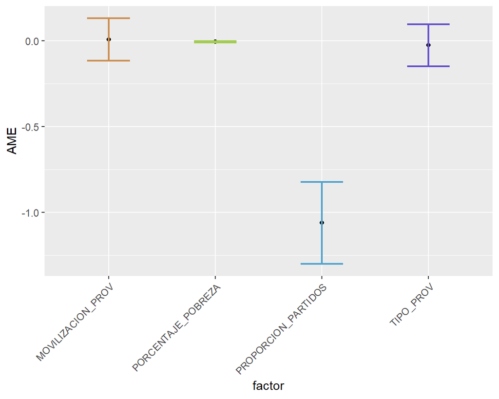

### ¿Qué quiere decir esto?

- De acuerdo con los resultados, si analizamos el éxito de que un movimiento regional gane, podemos observar que las variables tipo de provincia, movilización ciudadana y porcentaje de pobreza no tienen un efecto significativo en este resultado
- Sin embargo, si le agregamos la variable de control (proporción de partidos nacionales sobre partidos totales), podemos observar que la única variable que adquiere significancia es el porcentaje de pobreza con un impacto mínimo en la probabilidad del evento: que gane un partido regional